# Untitled

Juan Carlos Villaseñor-Derbez

January 23, 2018

### Exercise 3: Try it yourself!

> Try making any other modification to the SIR model that you’re interested in. For example, maybe individuals have to go through an exposed class after they become infected, but before they are infectious. Or, maybe some fraction of the population gets vaccinated and has a reduced susceptibility to the virus. You decide. Explore your modification to the model using numerical simulations.

The standard SIR model is:

$$\begin{align}
\frac{d S}{dt} &= -\beta I S\\
\frac{d I}{dt} &= \beta I S - \gamma I \\
\frac{d R}{dt} &= \gamma I
\end{align}$$

By including vaccination, the SIR model incorporates vaccination rate $v$ as follows:

$$\begin{align}
\frac{d S}{dt} &= -\beta I S -v S\\
\frac{d I}{dt} &= \beta I S - \gamma I \\
\frac{d R}{dt} &= \gamma I + v S
\end{align}$$

The term $vS$ indicates the proportion $v$ of suceptible individuals $S$ that receive a shot at every timestep.

```r
suppressPackageStartupMessages({
  library(deSolve)
  library(cowplot)
  library(tidyverse)
})
```

```r
SIRv.model <- function (t, x, params) {
  S = x[1]
  I = x[2]
  R = x[3]

  beta = params[1]
  gamma = params[2]
  v = params[3]

  dSdt = (-beta*S*I) - v*S
  dIdt = (beta*S*I) - (gamma*I)
  dRdt = (gamma*I) + v*S

 return(list(c(dSdt,dIdt,dRdt)))
}
```

## Define initial conditions:

We can evaluate a model without vaccination by setting $v = 0$. Let’s compare both models:

```r
S0 = 99 # Initial number of susceptibles
I0 = 1 # Initial number of infecteds
R0 = 0 # Initial number of recovered
initial_values = c(S=S0,I=I0,R=R0)

beta = 0.1 # per host per week
gamma = 1 # per week
v = 0.5 # per week

parameters = c(beta, gamma, 0) # parameters without vaccination
parameters_v = c(beta,gamma, v) # parameters with vaccination

times = seq(0, 10, by=0.01)
```

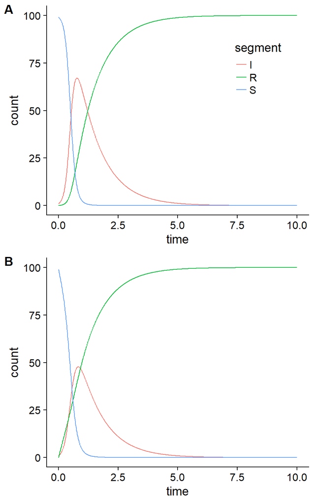

```r
SIR_plot <- lsoda(initial_values, times, SIRv.model, parameters) %>%
  as.data.frame() %>%
  gather(segment, count, -time) %>%
  ggplot(aes(time, count, color = segment)) +
  geom_line() +
  theme(legend.position = c(0.7, 0.7))

SIR_v_plot <- lsoda(initial_values, times, SIRv.model, parameters_v) %>%
  as.data.frame() %>%
  gather(segment, count, -time) %>%
  ggplot(aes(time, count, color = segment)) +
  geom_line() +
  theme(legend.position = "none")

cowplot::plot_grid(SIR_plot, SIR_v_plot, labels = c("A", "B"), ncol = 1)
```